# Transition Network Analysis (TNA) Tutorial

## 9. Community Detection

Communities comprise nodes more closely related or densely interconnected together than to other network nodes. In TNA, communities group states or events that frequently transition between one another or share similar dynamics. Communities represent cohesive sequences or activity successions that are more likely to co-occur, revealing typical pathways or recurring behaviors.

Unlike cliques — which maintain fixed or predefined structures (2-cliques or 3-cliques) — communities are data-driven based on connectivity patterns, making them more descriptive of real-world structures. Community identification uncovers latent or hidden clusters of related interaction or behavior during learning. Identifying these clusters provides insight into collaboration and learning effectiveness, common regulatory practices, or interaction patterns.

Furthermore, identifying behavior or event communities can contribute to theory building and learning understanding. These communities represent underlying interaction pattern inferences from densely connected behaviors into simplified meaningful structures, suggesting the presence of underlying constructs or behavioral mechanisms.

The `communities()` function supports several detection algorithms suited for transition networks (typically small, weighted, and directed):

- **Leading Eigenvector** (`leading_eigen`): Uses the leading eigenvector of the modularity matrix to partition nodes. This is the default method.
- **Fast Greedy** (`fast_greedy`): Optimizes modularity by iteratively merging communities.
- **Louvain** (`louvain`): A multi-level modularity optimization algorithm.
- **Label Propagation** (`label_prop`): Each node adopts the most common community among its neighbors.
- **Edge Betweenness** (`edge_betweenness`): Iteratively removes high-betweenness edges to reveal communities.

```python
# Detect communities using the default algorithm (leading eigenvector)
comms = tna.communities(model)
print(comms)
```

```
Community Detection Results

  leading_eigen: 2 communities

Assignments:
            leading_eigen
adapt                   0
cohesion                0
consensus               0
coregulate              1
discuss                 1
emotion                 0
monitor                 1
plan                    1
synthesis               0
```

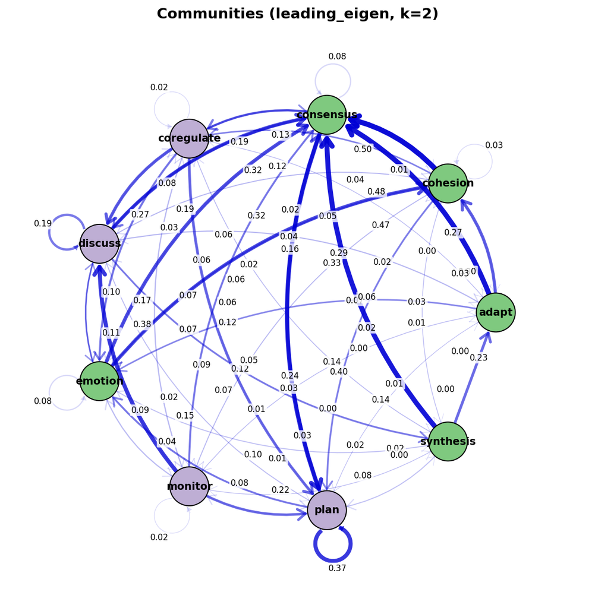

```python
# Plot communities: nodes colored by community assignment
tna.plot_communities(comms, cut=0.1)
plt.show()
```

```python
# Try multiple community detection methods
comms_multi = tna.communities(model, methods=["leading_eigen", "louvain", "fast_greedy"])
print(comms_multi)
```

```
Community Detection Results

  leading_eigen: 2 communities
  louvain: 2 communities
  fast_greedy: 2 communities

Assignments:
            leading_eigen  louvain  fast_greedy
adapt                   0        0            0
cohesion                0        0            0
consensus               0        0            0
coregulate              1        1            1
discuss                 1        1            1
emotion                 0        0            0
monitor                 1        1            1
plan                    1        0            0
synthesis               0        0            0
```

## 10. Bootstrapping

### 10.1 Why Bootstrap?

Bootstrapping represents a robust validation technique for assessing edge-weight accuracy and stability, consequently validating entire models. Through bootstrapping, researchers verify each edge, determine statistical significance, and obtain transition probability confidence intervals. Most network or process mining research employs descriptive methods — model validation or statistical significance proving remain largely absent from the literature. Validated models enable researchers to assess robustness and reproducibility, ensuring insights arise not from chance and therefore remain generalizable.

Bootstrapping — a resampling technique — involves repeatedly drawing samples from original datasets **with replacement** to estimate models for each sample (usually hundreds or thousands of times). Bootstrapping requires no strong data distribution assumptions, rendering it suitable for process data analysis that often does not adhere to specific distributions. Given bootstrap replacement, each sample may include multiple copies of some observations while excluding others, assessing parameter estimate variability. Edges consistently appearing across most estimated models prove stable and significant.

Another key bootstrap advantage involves effectively pruning dense networks. One challenge in probabilistic networks like TNA involves common complete connection — meaning every possible node connection exists to some degree. Bootstrapping mitigates this by identifying and eliminating small and uncertain edges, effectively retrieving the network backbone. The resulting simplified network proves easier to interpret and more likely to be generalizable.

The `bootstrap_tna()` function calculates confidence intervals and p-values for each edge weight. The function features a default of 1000 bootstrap iterations (via the `iter` argument). The `level` argument sets the significance threshold (e.g., 0.05) — if edges consistently appear above this threshold in bootstrapped samples, they are deemed statistically significant.

```python
# Resample sequences 1000 times and assess edge stability
np.random.seed(265)  # for reproducibility
boot = tna.bootstrap_tna(model, iter=1000, level=0.05, seed=265)
```

### 10.2 Results

The bootstrap result contains several elements:

- **`weights_sig`**: A matrix showing only statistically significant transitions (non-significant weights set to zero)
- **`weights_mean`**: Mean transition matrix across all bootstrap samples
- **`weights_sd`**: Standard deviation matrix across all bootstrap samples
- **`ci_lower` / `ci_upper`**: Bootstrap confidence interval bounds for each transition
- **`p_values`**: Bootstrap p-value matrix for each transition

The `summary()` method returns a convenient DataFrame with all of these statistics per edge:

```python
# Extract the bootstrap summary table
boot_df = boot.summary()
boot_df.head(10)
```

|  | from | to | weight | p_value | sig | cr_lower | cr_upper | ci_lower | ci_upper |
| --- | --- | --- | --- | --- | --- | --- | --- | --- | --- |
| 0 | cohesion | adapt | 0.002950 | 0.480519 | False | 0.002212 | 0.003687 | 0.000594 | 0.005700 |
| 1 | consensus | adapt | 0.004740 | 0.173826 | False | 0.003555 | 0.005925 | 0.003130 | 0.006352 |
| 2 | coregulate | adapt | 0.016244 | 0.156843 | False | 0.012183 | 0.020305 | 0.010810 | 0.022272 |
| 3 | discuss | adapt | 0.071374 | 0.000999 | True | 0.053531 | 0.089218 | 0.063041 | 0.079214 |
| 4 | emotion | adapt | 0.002467 | 0.577423 | False | 0.001851 | 0.003084 | 0.000720 | 0.004458 |
| 5 | monitor | adapt | 0.011165 | 0.287712 | False | 0.008374 | 0.013957 | 0.006206 | 0.016417 |
| 6 | plan | adapt | 0.000975 | 0.550450 | False | 0.000731 | 0.001218 | 0.000320 | 0.001848 |
| 7 | synthesis | adapt | 0.234663 | 0.000999 | True | 0.175997 | 0.293328 | 0.202432 | 0.267998 |
| 8 | adapt | cohesion | 0.273084 | 0.001998 | True | 0.204813 | 0.341356 | 0.236137 | 0.310988 |
| 9 | cohesion | cohesion | 0.027139 | 0.108891 | False | 0.020354 | 0.033923 | 0.019429 | 0.035850 |

```python
# Keep only edges that survived the bootstrap and sort by weight
sig_edges = boot_df[boot_df["sig"] == True].sort_values("weight", ascending=False)
print(f"{len(sig_edges)} out of {len(boot_df)} edges are significant")
sig_edges.head(15)
```

```
51 out of 78 edges are significant
```

|  | from | to | weight | p_value | sig | cr_lower | cr_upper | ci_lower | ci_upper |
| --- | --- | --- | --- | --- | --- | --- | --- | --- | --- |
| 18 | cohesion | consensus | 0.497935 | 0.000999 | True | 0.373451 | 0.622419 | 0.475015 | 0.521243 |
| 17 | adapt | consensus | 0.477407 | 0.000999 | True | 0.358055 | 0.596758 | 0.431948 | 0.520174 |
| 25 | synthesis | consensus | 0.466258 | 0.000999 | True | 0.349693 | 0.582822 | 0.426488 | 0.505009 |
| 64 | consensus | plan | 0.395797 | 0.000999 | True | 0.296848 | 0.494746 | 0.383257 | 0.407910 |
| 41 | monitor | discuss | 0.375436 | 0.000999 | True | 0.281577 | 0.469295 | 0.352214 | 0.401393 |
| 69 | plan | plan | 0.374208 | 0.000999 | True | 0.280656 | 0.467760 | 0.362409 | 0.386589 |
| 13 | emotion | cohesion | 0.325344 | 0.000999 | True | 0.244008 | 0.406680 | 0.308078 | 0.342700 |
| 21 | discuss | consensus | 0.321185 | 0.000999 | True | 0.240888 | 0.401481 | 0.306922 | 0.336784 |
| 22 | emotion | consensus | 0.320409 | 0.000999 | True | 0.240307 | 0.400511 | 0.302499 | 0.337725 |
| 24 | plan | consensus | 0.290401 | 0.000999 | True | 0.217801 | 0.363001 | 0.278729 | 0.301506 |
| 38 | coregulate | discuss | 0.273604 | 0.000999 | True | 0.205203 | 0.342005 | 0.254195 | 0.291943 |
| 8 | adapt | cohesion | 0.273084 | 0.001998 | True | 0.204813 | 0.341356 | 0.236137 | 0.310988 |
| 65 | coregulate | plan | 0.239086 | 0.000999 | True | 0.179315 | 0.298858 | 0.218761 | 0.258977 |
| 7 | synthesis | adapt | 0.234663 | 0.000999 | True | 0.175997 | 0.293328 | 0.202432 | 0.267998 |
| 68 | monitor | plan | 0.215632 | 0.000999 | True | 0.161724 | 0.269539 | 0.194958 | 0.236826 |

### 10.3 Bootstrapped Network

The bootstrapped model (`boot.model`) contains only statistically significant edges — those that survived the bootstrap validation. Plotting this model shows the validated network backbone, which is more likely to generalize to new data:

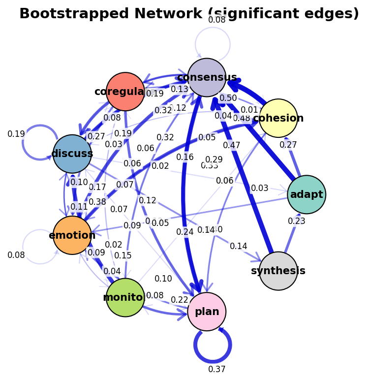

```python
# Plot the bootstrapped network (only significant edges)
tna.plot_network(boot.model, cut=0.1, title="Bootstrapped Network (significant edges)")
plt.show()
```

## 11. Sequence Plots

Sequence plots provide a direct visualization of the raw sequential data before it is aggregated into a transition network. These visualizations help researchers understand the variety and structure of individual sequences.

Two plot types are available:

- **Index plot**: Each row represents one sequence, with colors indicating the state at each position. This reveals the diversity and patterns in individual trajectories — whether sequences are highly varied or follow common templates.
- **Distribution plot**: Shows the proportion of each state at each sequence position, revealing how the state distribution evolves over time. This helps identify whether certain states dominate at the beginning or end of sequences.

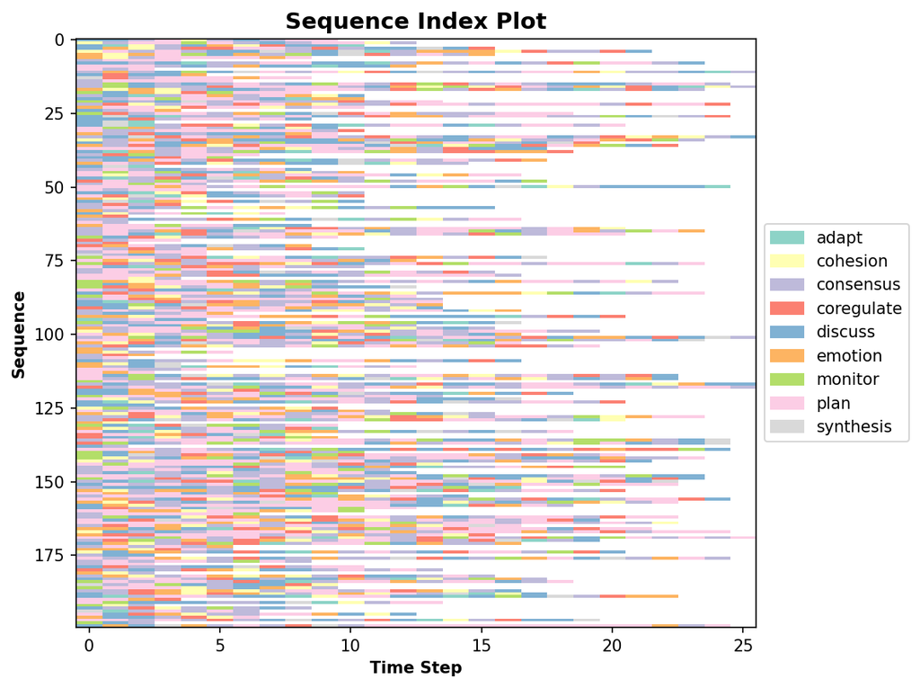

```python
# Each row is one sequence; colors represent states at each position
tna.plot_sequences(prepared_data, max_sequences=200)
plt.show()
```

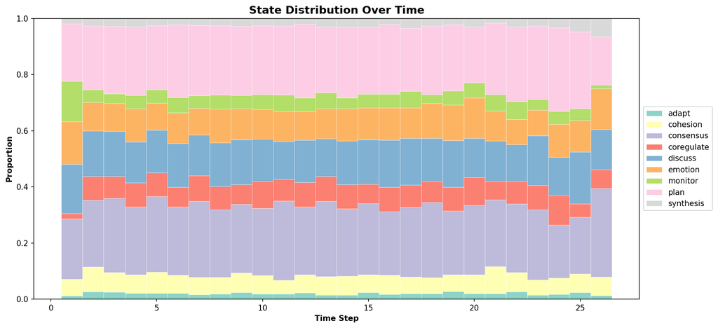

```python
# Proportion of each state at each sequence position
tna.plot_sequences(prepared_data, plot_type="distribution")
plt.show()
```

## 12. Group Models

Researchers frequently encounter predefined conditions — high versus low achievers, different course types, or gender groups. Comparing such groups has commonly occurred visually — comparing process models or sequence models. While visual comparison may reveal differences, it fails to indicate statistical significance. Where precisely differences prove statistically significant and where they do not remains unclear.

TNA addresses this by enabling rigorous systematic group comparison. The `group_tna()` function builds separate TNA models for each level of a grouping variable. The metadata preserved by `prepare_data()` (e.g., the **Achiever** column) can be used directly as the grouping variable — no manual data splitting needed.

All standard TNA functions (`centralities()`, `prune()`, `communities()`, `cliques()`, `plot_network()`) work seamlessly with group models, automatically applying per-group and returning combined results. This enables researchers to examine how transition dynamics differ across subgroups without writing any group-splitting code.

```python
# Build group models directly from the prepared data using the Achiever metadata column
group_model = tna.group_tna(prepared_data, group="Achiever")
print(group_model)
print()

# Summary statistics per group
group_model.summary()
```

```
GroupTNA with 2 groups:
  High: 9 states, 76 edges
  Low: 9 states, 75 edges
```

| group | n_states | type | scaling | n_edges | density | mean_weight | max_weight | has_self_loops |
| --- | --- | --- | --- | --- | --- | --- | --- | --- |
| High | 9 | relative | [] | 76 | 0.938272 | 0.118421 | 0.575540 | True |
| Low | 9 | relative | [] | 75 | 0.925926 | 0.120000 | 0.461957 | True |

```python
# Access individual models using dict-style indexing
print(group_model["High"])
print()
print("Group names:", group_model.names())
```

```
TNA Model
  Type: relative
  States: ['adapt', 'cohesion', 'consensus', 'coregulate', 'discuss', 'emotion', 'monitor', 'plan', 'synthesis']
  Scaling: none

Transition Matrix:
               adapt  cohesion  consensus  coregulate   discuss   emotion   monitor      plan  synthesis
adapt       0.000000  0.262411   0.517730    0.000000  0.035461  0.141844  0.028369  0.014184   0.000000
cohesion    0.005330  0.043710   0.536247    0.081023  0.040512  0.118337  0.017058  0.151386   0.006397
consensus   0.004127  0.019752   0.083432    0.170991  0.232606  0.081368  0.035377  0.364387   0.007960
coregulate  0.022371  0.035794   0.108501    0.013423  0.234899  0.203579  0.096197  0.266219   0.019016
discuss     0.023964  0.061907   0.424863    0.072391  0.169246  0.112332  0.016475  0.012481   0.106340
emotion     0.003226  0.325806   0.336129    0.023226  0.121935  0.062581  0.031613  0.090323   0.005161
monitor     0.011058  0.048973   0.159558    0.050553  0.369668  0.096367  0.018957  0.225908   0.018957
plan        0.001383  0.031466   0.293914    0.023859  0.060166  0.182227  0.075726  0.327801   0.003458
synthesis   0.143885  0.028777   0.575540    0.014388  0.028777  0.064748  0.000000  0.143885   0.000000

Initial Probabilities:
             prob
adapt       0.012
cohesion    0.082
consensus   0.212
coregulate  0.005
discuss     0.180
emotion     0.169
monitor     0.129
plan        0.188
synthesis   0.023

Group names: ['High', 'Low']
```

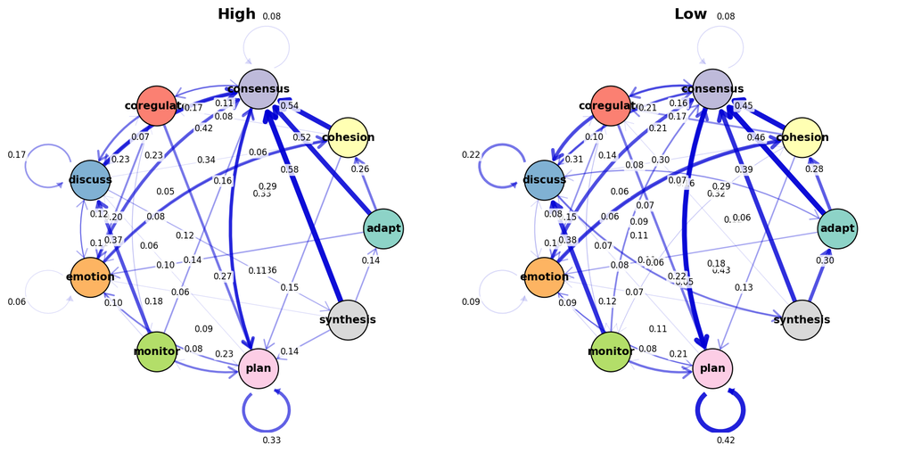

```python
# Plot all group networks side by side (automatic multi-panel)
tna.plot_network(group_model, minimum=0.05, cut=0.1)
plt.show()
```

```python
# Prune all groups at once — returns a new GroupTNA with pruned models
pruned_group = tna.prune(group_model, threshold=0.05)
print(pruned_group)

# Compare edge counts
for name in group_model:
    orig = group_model[name].summary()["n_edges"]
    prun = pruned_group[name].summary()["n_edges"]
    print(f"  {name}: {orig} → {prun} edges")
```

```
GroupTNA with 2 groups:
  High: 9 states, 42 edges
  Low: 9 states, 48 edges
  High: 76 → 42 edges
  Low: 75 → 48 edges
```

```python
# Centralities across groups — returns a single DataFrame with a 'group' column
group_cent = tna.centralities(group_model, measures=["OutStrength", "InStrength", "Betweenness"])
group_cent
```

|  | group | OutStrength | InStrength | Betweenness |
| --- | --- | --- | --- | --- |
| adapt | High | 1.000000 | 0.215346 | 1.0 |
| cohesion | High | 0.956290 | 0.814888 | 0.0 |
| consensus | High | 0.916568 | 2.952482 | 30.0 |
| coregulate | High | 0.986577 | 0.436432 | 0.0 |
| discuss | High | 0.830754 | 1.124025 | 16.0 |
| emotion | High | 0.937419 | 1.000801 | 5.0 |
| monitor | High | 0.981043 | 0.300815 | 0.0 |
| plan | High | 0.672199 | 1.268773 | 11.0 |
| synthesis | High | 1.000000 | 0.167289 | 7.0 |
| adapt | Low | 1.000000 | 0.452279 | 4.0 |
| cohesion | Low | 0.993395 | 0.798538 | 0.0 |
| consensus | Low | 0.919646 | 2.415674 | 25.0 |
| coregulate | Low | 0.968401 | 0.689185 | 3.0 |
| discuss | Low | 0.778747 | 1.214121 | 14.0 |
| emotion | Low | 0.905983 | 0.807917 | 3.0 |
| monitor | Low | 0.982500 | 0.392745 | 0.0 |
| plan | Low | 0.584686 | 1.146514 | 8.0 |
| synthesis | Low | 1.000000 | 0.216385 | 0.0 |

```python
# Communities per group
group_comms = tna.communities(group_model)
for name, result in group_comms.items():
    print(f"{name}: {result.counts}")
    print(result.assignments)
    print()
```

```
High: {'leading_eigen': 2}
            leading_eigen
adapt                   1
cohesion                1
consensus               1
coregulate              0
discuss                 0
emotion                 1
monitor                 0
plan                    0
synthesis               1

Low: {'leading_eigen': 2}
            leading_eigen
adapt                   0
cohesion                0
consensus               0
coregulate              1
discuss                 1
emotion                 1
monitor                 1
plan                    1
synthesis               0
```

### 12.1 Permutation Testing Between Groups

To address the limitations of simple visual comparison, TNA employs rigorous permutation-based approaches for determining whether observed differences between group models are statistically significant. Permutation tests involve repeatedly shuffling the data between groups and generating a distribution of differences under the null hypothesis. For each edge, the test provides p-values helping researchers identify statistically significant differences. This rigorous approach ensures TNA insights reflect true underlying differences rather than chance artifacts.

The `permutation_test()` function compares two TNA models by shuffling sequences between groups for a specified number of iterations (`iter`), creating a null distribution of edge-weight differences. Edges where the observed difference exceeds the permutation distribution are flagged as statistically significant.

Access individual group models with dict-style indexing to compare specific groups:

```python
# Permutation test: compare High vs Low achievers
perm_result = tna.permutation_test(
    group_model["High"], group_model["Low"],
    iter=500, seed=42, level=0.05
)

# Show significant edge differences
sig_perm = perm_result.edges["stats"][
    perm_result.edges["stats"]["p_value"] < 0.05
].sort_values("p_value")

print(f"{len(sig_perm)} significant edge differences found")
sig_perm
```

```
42 significant edge differences found
```

|  | edge_name | diff_true | effect_size | p_value |
| --- | --- | --- | --- | --- |
| 38 | consensus -> discuss | 0.096072 | 9.800758 | 0.001996 |
| 76 | discuss -> synthesis | -0.070251 | -6.280752 | 0.001996 |
| 71 | synthesis -> plan | 0.119821 | 5.892463 | 0.001996 |
| 70 | plan -> plan | -0.087513 | -6.955485 | 0.001996 |
| 65 | consensus -> plan | -0.067687 | -5.392796 | 0.001996 |
| 56 | consensus -> monitor | -0.024207 | -4.640464 | 0.001996 |
| 55 | cohesion -> monitor | -0.035783 | -3.962377 | 0.001996 |
| 52 | plan -> emotion | 0.066760 | 7.404535 | 0.001996 |
| 48 | coregulate -> emotion | 0.057669 | 3.479972 | 0.001996 |
| 41 | emotion -> discuss | 0.044235 | 3.682664 | 0.001996 |
| 40 | discuss -> discuss | -0.052006 | -4.281572 | 0.001996 |
| 39 | coregulate -> discuss | -0.070863 | -3.543739 | 0.001996 |
| 37 | cohesion -> discuss | -0.042712 | -3.940997 | 0.001996 |
| 32 | emotion -> coregulate | -0.024171 | -3.693955 | 0.001996 |
| 79 | plan -> synthesis | 0.003152 | 2.898779 | 0.001996 |
| 10 | cohesion -> cohesion | 0.037105 | 4.679806 | 0.001996 |
| 13 | discuss -> cohesion | 0.029053 | 4.234649 | 0.001996 |
| 19 | cohesion -> consensus | 0.085785 | 3.377973 | 0.001996 |
| 22 | discuss -> consensus | 0.210284 | 14.505543 | 0.001996 |
| 26 | synthesis -> consensus | 0.190513 | 4.781482 | 0.001996 |
| 8 | synthesis -> adapt | -0.158254 | -4.827859 | 0.001996 |
| 11 | consensus -> cohesion | 0.010559 | 3.786004 | 0.001996 |
| 28 | cohesion -> coregulate | -0.085423 | -5.210336 | 0.001996 |
| 29 | consensus -> coregulate | -0.036023 | -3.396109 | 0.001996 |
| 4 | discuss -> adapt | -0.096159 | -11.276056 | 0.001996 |
| 35 | synthesis -> coregulate | -0.052456 | -3.108636 | 0.003992 |
| 44 | synthesis -> discuss | -0.059458 | -3.182909 | 0.003992 |
| 47 | consensus -> emotion | 0.018719 | 2.944978 | 0.003992 |
| 21 | coregulate -> consensus | -0.047633 | -3.175563 | 0.003992 |
| 30 | coregulate -> coregulate | -0.018176 | -2.675244 | 0.003992 |
| 34 | plan -> coregulate | 0.012527 | 3.697559 | 0.003992 |
| 16 | plan -> cohesion | 0.011864 | 2.942219 | 0.003992 |
| 50 | emotion -> emotion | -0.031436 | -2.888892 | 0.005988 |
| 66 | coregulate -> plan | 0.049676 | 2.613874 | 0.009980 |
| 31 | discuss -> coregulate | -0.024118 | -2.733761 | 0.009980 |
| 77 | emotion -> synthesis | 0.005161 | 2.661137 | 0.009980 |
| 62 | synthesis -> monitor | -0.021390 | -2.597739 | 0.011976 |
| 58 | discuss -> monitor | -0.011759 | -2.517596 | 0.013972 |
| 43 | plan -> discuss | -0.014566 | -2.266660 | 0.019960 |
| 27 | adapt -> coregulate | -0.029891 | -2.360321 | 0.023952 |
| 73 | cohesion -> synthesis | 0.006397 | 2.195816 | 0.033932 |
| 3 | coregulate -> adapt | 0.011219 | 1.999853 | 0.049900 |

### 12.2 Difference Network

The `plot_compare()` function visualizes the difference between two TNA models as a network. Green edges indicate transitions that are stronger in the first model, red edges indicate transitions stronger in the second. Edge width is proportional to the absolute difference. Node colors reflect differences in initial probabilities:

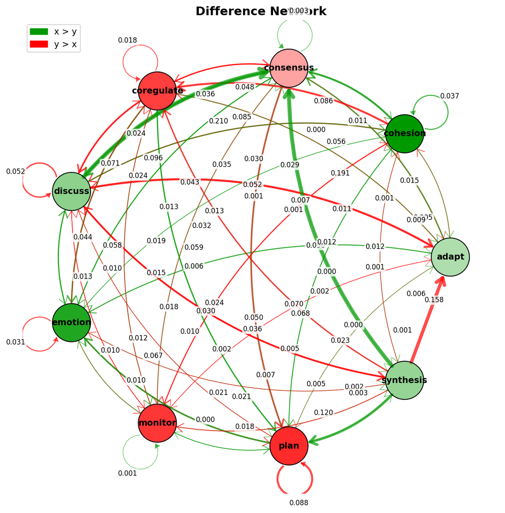

```python
# Difference network: High vs Low achievers
tna.plot_compare(group_model["High"], group_model["Low"])
plt.show()
```

### 12.3 Comparing Sequence Patterns

Beyond edge-level permutation tests and difference networks, TNA offers a complementary approach for group comparison that operates at the **subsequence level**. The `compare_sequences()` function extracts n-gram patterns — contiguous subsequences of length 1 (unigrams), 2 (bigrams), 3 (trigrams), and so on — from each group's raw sequences and compares their frequencies.

This approach answers a different question than permutation testing. Where permutation tests ask "do these two groups differ in their *transition probabilities*?", sequence pattern comparison asks "do these two groups differ in the *specific behavioral sequences* they produce?" For example, a bigram `"plan->consensus"` captures a concrete two-step behavior, while a transition probability `plan→consensus` is an aggregate over all sequences.

The `sub` parameter controls which subsequence lengths to examine (default: 1 through 5), and `min_freq` filters out rare patterns that appear fewer than a specified number of times in any group. When `test=True`, a permutation test shuffles group labels to assess whether the observed frequency differences are statistically significant, with p-values adjusted for multiple comparisons (Bonferroni by default).

```python
# Compare subsequence patterns between High and Low achievers
cs_result = tna.compare_sequences(group_model)
print(f"Total patterns found: {len(cs_result)}")
print(f"Columns: {list(cs_result.columns)}")
print()

# Show unigrams (single-state frequencies)
unigrams = cs_result[~cs_result['pattern'].str.contains('->')]
print(f"Unigram patterns ({len(unigrams)} states):")
print(unigrams.to_string(index=False))
print()

# Show top bigrams by frequency difference
bigrams = cs_result[cs_result['pattern'].str.count('->') == 1].copy()
bigrams['prop_diff'] = (bigrams['prop_High'] - bigrams['prop_Low']).abs()
print(f"Top 10 bigrams by proportion difference ({len(bigrams)} total):")
bigrams.nlargest(10, 'prop_diff')[['pattern', 'freq_High', 'freq_Low', 'prop_High', 'prop_Low']]
```

```
Total patterns found: 918
Columns: ['pattern', 'freq_High', 'freq_Low', 'prop_High', 'prop_Low']

Unigram patterns (9 states):
   pattern  freq_High  freq_Low  prop_High  prop_Low
     adapt        155       399   0.011297  0.028888
  cohesion       1018       821   0.074193  0.059441
 consensus       3651      3146   0.266088  0.227773
coregulate        959      1174   0.069893  0.084999
   discuss       2166      2101   0.157860  0.152114
   emotion       1686      1389   0.122877  0.100565
   monitor        668       848   0.048684  0.061396
      plan       3102      3521   0.226077  0.254923
 synthesis        316       413   0.023030  0.029902

Top 10 bigrams by proportion difference (67 total):
```

|  | pattern | freq_High | freq_Low | prop_High | prop_Low |
| --- | --- | --- | --- | --- | --- |
| 40 | discuss->consensus | 851 | 418 | 0.066897 | 0.032626 |
| 69 | plan->plan | 948 | 1356 | 0.074522 | 0.105838 |
| 24 | consensus->discuss | 789 | 401 | 0.062023 | 0.031299 |
| 38 | discuss->adapt | 48 | 234 | 0.003773 | 0.018264 |
| 14 | cohesion->consensus | 503 | 341 | 0.039541 | 0.026616 |
| 67 | plan->emotion | 527 | 377 | 0.041428 | 0.029426 |
| 48 | emotion->consensus | 521 | 388 | 0.040956 | 0.030284 |
| 46 | discuss->synthesis | 213 | 344 | 0.016744 | 0.026850 |
| 33 | coregulate->discuss | 210 | 329 | 0.016508 | 0.025679 |
| 10 | adapt->consensus | 73 | 170 | 0.005739 | 0.013269 |

```python
# Permutation test for statistical significance (100 iterations for speed)
cs_test = tna.compare_sequences(group_model, test=True, iter_=100, seed=42)

# Show patterns with smallest p-values
print("Patterns with smallest adjusted p-values:")
cs_test.head(15)[['pattern', 'freq_High', 'freq_Low', 'prop_High', 'prop_Low', 'effect_size', 'p_value']]
```

```
Patterns with smallest adjusted p-values:
```

|  | pattern | freq_High | freq_Low | prop_High | prop_Low | effect_size | p_value |
| --- | --- | --- | --- | --- | --- | --- | --- |
| 0 | adapt | 155 | 399 | 0.011297 | 0.028888 | 15.838830 | 0.089109 |
| 1 | cohesion | 1018 | 821 | 0.074193 | 0.059441 | 7.453087 | 0.089109 |
| 2 | consensus | 3651 | 3146 | 0.266088 | 0.227773 | 14.827639 | 0.089109 |
| 3 | coregulate | 959 | 1174 | 0.069893 | 0.084999 | 6.394814 | 0.089109 |
| 4 | emotion | 1686 | 1389 | 0.122877 | 0.100565 | 11.488188 | 0.089109 |
| 5 | monitor | 668 | 848 | 0.048684 | 0.061396 | 6.937058 | 0.089109 |
| 6 | plan | 3102 | 3521 | 0.226077 | 0.254923 | 7.138419 | 0.089109 |
| 7 | synthesis | 316 | 413 | 0.023030 | 0.029902 | 4.255809 | 0.089109 |
| 8 | adapt->cohesion | 37 | 102 | 0.002909 | 0.007961 | 8.969993 | 0.772277 |
| 9 | adapt->consensus | 73 | 170 | 0.005739 | 0.013269 | 8.197910 | 0.772277 |
| 10 | adapt->discuss | 5 | 25 | 0.000393 | 0.001951 | 5.433557 | 0.772277 |
| 11 | cohesion->cohesion | 41 | 5 | 0.003223 | 0.000390 | 8.096168 | 0.772277 |
| 12 | cohesion->consensus | 503 | 341 | 0.039541 | 0.026616 | 9.826334 | 0.772277 |
| 13 | cohesion->monitor | 16 | 40 | 0.001258 | 0.003122 | 4.703406 | 0.772277 |
| 14 | cohesion->plan | 142 | 97 | 0.011163 | 0.007571 | 3.205518 | 0.772277 |

## 13. Sequence Clustering (Tactics)

### 13.1 Why Cluster Sequences?

The analyses presented so far — transition networks, centralities, communities, bootstrapping, and group comparison — all operate at the **network level**, characterizing the aggregate dynamics of how states connect and transition. However, within any dataset, individual sequences often exhibit substantial heterogeneity. Not all learners follow the same behavioral patterns. Some may consistently cycle between planning and execution, while others predominantly engage in monitoring with occasional social interactions.

Sequence clustering addresses this heterogeneity by grouping **individual sequences** (learners, sessions, or actors) into clusters of similar behavioral trajectories — often called **tactics** or **strategies** in educational research. This complements network-level analysis by revealing the diversity of approaches within a population. Where the overall TNA model shows the average transition structure, tactics reveal the distinct behavioral patterns that compose that average.

This distinction from community detection (Section 9) is important. Communities group **states** that frequently co-transition within the network — identifying which behaviors tend to co-occur. Tactics group **entire sequences** — identifying which learners behave similarly across their full trajectory. A learner's tactic reflects their overall strategy, while communities reflect structural relationships among behaviors.

Identifying tactics serves several research purposes:

- **Typology development**: Discovering naturally occurring behavioral patterns supports theory building about learning strategies, self-regulation approaches, or collaborative styles.
- **Intervention targeting**: Different tactics may require different interventions. Learners who predominantly monitor but rarely plan may benefit from different support than those who cycle rapidly between all states.
- **Outcome prediction**: Tactics can predict learning outcomes — some behavioral patterns may consistently associate with higher or lower achievement.
- **Group comparison via TNA**: Perhaps most powerfully, discovered tactics can serve as grouping variables for further TNA analysis, building separate transition networks per tactic to examine how transition dynamics differ across behavioral strategies.

### 13.2 Distance Metrics

Sequence clustering requires measuring how similar or different two sequences are. The `cluster_sequences()` function supports four distance metrics, each capturing different aspects of sequence similarity:

- **Hamming distance** (`'hamming'`): Counts the number of positions where two sequences differ. Fast and intuitive, but requires sequences of equal length and treats all positions equally. Best suited for aligned sequences where positional correspondence matters — for example, comparing what students did at time step 1, time step 2, etc.
- **Levenshtein distance** (`'lv'`): The minimum number of insertions, deletions, and substitutions needed to transform one sequence into another. Handles unequal-length sequences naturally. Appropriate when the exact temporal alignment is less important than the overall ordering of events.
- **Optimal String Alignment** (`'osa'`): Extends Levenshtein distance by also allowing adjacent transpositions (swapping two neighboring elements). Useful when near-swaps should be considered minor differences — for example, if planning-then-executing versus executing-then-planning represents a small rather than large behavioral difference.
- **Longest Common Subsequence** (`'lcs'`): Measures distance as the length difference after removing the longest shared subsequence. Focuses on what two sequences have in common regardless of position. Particularly appropriate when the presence of certain behavioral patterns matters more than their exact timing.

For most TNA applications with aligned sequences from `prepare_data()`, Hamming distance provides a good default. For sequences of varying length or when positional alignment is uncertain, Levenshtein or LCS distances are more appropriate.

```python
# Cluster sequences into 3 tactics using PAM with Hamming distance
clust = tna.cluster_sequences(prepared_data, k=3, dissimilarity="hamming", method="pam")
print(clust)
print(f"\nCluster sizes: {clust.sizes}")
print(f"Silhouette score: {clust.silhouette:.4f}")
```

```
ClusterResult(k=3, method='pam', dissimilarity='hamming', silhouette=0.1904)

Cluster sizes: [893 713 394]
Silhouette score: 0.1904
```

### 13.3 Clustering Methods

Two families of clustering methods are available:

**Partitioning Around Medoids (PAM)** (`method='pam'`) is the default and generally recommended method. PAM identifies *medoid* sequences — actual sequences from the data that best represent each cluster center. Unlike k-means (which uses abstract centroids), PAM's medoids are real, interpretable sequences that researchers can examine directly. PAM is also more robust to outliers than centroid-based methods.

**Hierarchical clustering** builds a tree-like dendrogram by iteratively merging the most similar sequences or clusters. The tree is then cut at the desired number of clusters. Several linkage methods control how inter-cluster distances are computed:

- `'complete'` — maximum distance between any pair across clusters (produces compact, spherical clusters)
- `'average'` — mean distance between all pairs across clusters (balanced approach)
- `'ward.D'` / `'ward.D2'` — minimizes within-cluster variance (tends to produce equal-sized clusters)
- `'single'` — minimum distance between any pair across clusters (can produce elongated, chain-like clusters)

The choice of method and distance metric can substantially affect results. Comparing multiple configurations and evaluating silhouette scores helps identify the most meaningful clustering for your data.

```python
# Compare distance metrics (using first 200 sequences for slower metrics)
subset = prepared_data.sequence_data.iloc[:200]
print("Distance metric comparison (PAM, k=3, n=200):")
for metric in ["hamming", "lcs", "osa"]:
    result = tna.cluster_sequences(subset, k=3, dissimilarity=metric)
    print(f"  {metric:>7s}: sizes={result.sizes}, silhouette={result.silhouette:.4f}")

print("\nLinkage method comparison (Hamming, k=3, full data):")
for method in ["pam", "complete", "average", "ward.D2"]:
    result = tna.cluster_sequences(prepared_data, k=3, method=method)
    print(f"  {method:>8s}: sizes={result.sizes}, silhouette={result.silhouette:.4f}")
```

```
Distance metric comparison (PAM, k=3, n=200):
  hamming: sizes=[77 53 70], silhouette=0.1372
```

```
      lcs: sizes=[74 80 46], silhouette=0.2048
```

```
      osa: sizes=[78 76 46], silhouette=0.1496

Linkage method comparison (Hamming, k=3, full data):
```

```
       pam: sizes=[893 713 394], silhouette=0.1904
```

```
  complete: sizes=[1639  108  253], silhouette=0.2831
```

```
   average: sizes=[1768  230    2], silhouette=0.3064
```

```
   ward.D2: sizes=[1130  377  493], silhouette=0.2354
```

### 13.4 Choosing the Number of Clusters

Selecting the appropriate number of clusters is a critical decision. The **silhouette score** measures how well each sequence fits its assigned cluster compared to the nearest alternative cluster. Values range from -1 (poor fit) to +1 (excellent fit), with higher mean silhouette scores indicating better-separated, more cohesive clusters.

A practical approach is to compute silhouette scores for a range of *k* values and select the *k* that maximizes the score — or the *k* where the score plateaus, indicating diminishing returns from additional clusters. Domain knowledge should also inform the decision: the identified clusters should be interpretable and meaningful in the research context.

```python
# Sweep k values and compare silhouette scores
print("Silhouette scores for different k values:")
for k in range(2, 6):
    result = tna.cluster_sequences(prepared_data, k=k)
    print(f"  k={k}: silhouette={result.silhouette:.4f}, sizes={result.sizes}")
```

```
Silhouette scores for different k values:
```

```
  k=2: silhouette=0.1839, sizes=[ 982 1018]
```

```
  k=3: silhouette=0.1904, sizes=[893 713 394]
```

```
  k=4: silhouette=0.1161, sizes=[606 455 351 588]
```

```
  k=5: silhouette=0.1277, sizes=[330 475 220 657 318]
```

### 13.5 Building TNA Models per Tactic

The most powerful application of sequence clustering in TNA is using the discovered tactics as grouping variables to build separate transition networks per cluster. This reveals how transition dynamics differ across behavioral strategies — for example, whether learners in a "monitoring-heavy" tactic show different transition patterns than those in a "planning-heavy" tactic.

The workflow is straightforward: cluster the sequences, assign each sequence to its tactic, and use `group_tna()` with the tactic labels as the grouping variable. All standard TNA functions — centralities, pruning, communities, bootstrapping, permutation testing — then work seamlessly on the tactic-based group model.

```python
# Step 1: Cluster sequences into tactics
clust = tna.cluster_sequences(prepared_data, k=3, dissimilarity="hamming", method="pam")

# Step 2: Add tactic labels to the sequence data
tactic_data = prepared_data.sequence_data.copy()
tactic_data["Tactic"] = [f"Tactic {c}" for c in clust.assignments]

# Step 3: Build a TNA model for each tactic
tactic_model = tna.group_tna(tactic_data, group="Tactic")
print(tactic_model)
print()
tactic_model.summary()
```

```
GroupTNA with 3 groups:
  Tactic 1: 9 states, 78 edges
  Tactic 2: 9 states, 78 edges
  Tactic 3: 9 states, 76 edges
```

| group | n_states | type | scaling | n_edges | density | mean_weight | max_weight | has_self_loops |
| --- | --- | --- | --- | --- | --- | --- | --- | --- |
| Tactic 1 | 9 | relative | [] | 78 | 0.962963 | 0.115385 | 0.476440 | True |
| Tactic 2 | 9 | relative | [] | 78 | 0.962963 | 0.115385 | 0.492308 | True |
| Tactic 3 | 9 | relative | [] | 76 | 0.938272 | 0.118421 | 0.542373 | True |

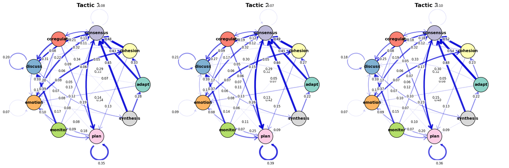

```python
# Compare transition networks across tactics
tna.plot_network(tactic_model, minimum=0.05, cut=0.1)
plt.show()
```

```python
# Centralities per tactic — which states are central in each behavioral strategy?
tactic_cent = tna.centralities(tactic_model, measures=["OutStrength", "InStrength", "Betweenness"])
tactic_cent
```

|  | group | OutStrength | InStrength | Betweenness |
| --- | --- | --- | --- | --- |
| adapt | Tactic 1 | 1.000000 | 0.398774 | 1.0 |
| cohesion | Tactic 1 | 0.979058 | 0.893311 | 0.0 |
| consensus | Tactic 1 | 0.917638 | 2.569952 | 30.0 |
| coregulate | Tactic 1 | 0.979112 | 0.572448 | 0.0 |
| discuss | Tactic 1 | 0.802787 | 1.273517 | 16.0 |
| emotion | Tactic 1 | 0.928025 | 0.991482 | 5.0 |
| monitor | Tactic 1 | 0.971989 | 0.362192 | 0.0 |
| plan | Tactic 1 | 0.650228 | 0.974802 | 9.0 |
| synthesis | Tactic 1 | 1.000000 | 0.192359 | 7.0 |
| adapt | Tactic 2 | 1.000000 | 0.330303 | 1.0 |
| cohesion | Tactic 2 | 0.966667 | 0.817223 | 0.0 |
| consensus | Tactic 2 | 0.929478 | 2.590660 | 30.0 |
| coregulate | Tactic 2 | 0.978070 | 0.582732 | 0.0 |
| discuss | Tactic 2 | 0.794239 | 1.160634 | 16.0 |
| emotion | Tactic 2 | 0.913286 | 0.862658 | 5.0 |
| monitor | Tactic 2 | 0.985600 | 0.330461 | 0.0 |
| plan | Tactic 2 | 0.606618 | 1.320666 | 11.0 |
| synthesis | Tactic 2 | 1.000000 | 0.178620 | 7.0 |
| adapt | Tactic 3 | 1.000000 | 0.326030 | 1.0 |
| cohesion | Tactic 3 | 0.977486 | 0.746947 | 0.0 |
| consensus | Tactic 3 | 0.903445 | 2.831315 | 30.0 |
| coregulate | Tactic 3 | 0.973333 | 0.542749 | 6.0 |
| discuss | Tactic 3 | 0.820805 | 1.175419 | 13.0 |
| emotion | Tactic 3 | 0.933118 | 0.877462 | 5.0 |
| monitor | Tactic 3 | 0.984479 | 0.354562 | 0.0 |
| plan | Tactic 3 | 0.640580 | 1.167881 | 3.0 |
| synthesis | Tactic 3 | 1.000000 | 0.210879 | 7.0 |

## 14. Complete Workflow at a Glance

The following code summarizes the full TNA analysis pipeline. This can serve as a template for your own analyses:

```
import tna
import pandas as pd

# 1. Load and prepare data
my_data = pd.read_csv("your_data.csv")
prepared = tna.prepare_data(my_data, action="event", actor="user_id", time="timestamp")

# 2. Build model
model = tna.tna(prepared)

# 3. Visualize
tna.plot_network(model, minimum=0.05, cut=0.1)
tna.plot_histogram(model)
tna.plot_frequencies(model)

# 4. Prune
pruned = tna.prune(model, threshold=0.05)
tna.plot_network(pruned, cut=0.1)

# 5. Cliques
print(tna.cliques(model, size=2, threshold=0.1))
print(tna.cliques(model, size=3, threshold=0.05))

# 6. Centralities
tna.plot_centralities(tna.centralities(model))
tna.plot_network(tna.betweenness_network(model), cut=0.1)

# 7. Communities
tna.plot_communities(tna.communities(model), cut=0.1)

# 8. Bootstrap
boot = tna.bootstrap_tna(model, iter=1000, level=0.05, seed=265)
tna.plot_network(boot.model, cut=0.1)

# 9. Sequences
tna.plot_sequences(prepared)

# 10. Group models (from metadata column)
gm = tna.group_tna(prepared, group="achievement")
tna.plot_network(gm)                    # side-by-side networks
tna.centralities(gm)                    # centralities with group column
tna.prune(gm, threshold=0.05)           # prune each group
tna.permutation_test(gm["A"], gm["B"])  # compare two groups
tna.compare_sequences(gm)               # compare sequence patterns
tna.compare_sequences(gm, test=True)    # with permutation test

# 11. Sequence clustering (tactics)
clust = tna.cluster_sequences(prepared, k=3, dissimilarity="hamming")
tactic_data = prepared.sequence_data.copy()
tactic_data["Tactic"] = [f"Tactic {c}" for c in clust.assignments]
tactic_model = tna.group_tna(tactic_data, group="Tactic")
tna.plot_network(tactic_model)          # per-tactic networks

# 12. Import one-hot encoded data
wide = tna.import_onehot(onehot_df, cols=["State_A", "State_B"], actor="id")
model_oh = tna.tna(wide)
```

For more information, see the [TNA package documentation](https://github.com/mohsaqr/tnapy) and the [R TNA tutorial](https://lamethods.org/book2/chapters/ch15-tna/ch15-tna.html) by Saqr & Lopez-Pernas.